# BlueHealthPass Knowledge Transfer - Tutorial on ML models and deployment

Erik Johannes Husom

2022-11-24

# Session 2: Hands-on tutorial

# Session 2 outline

- Summary session 1
- Requirements
- Installation
- Creating ML models walkthrough
  1. Restructuring data
  2. Running the pipeline
  3. Evaluating the results
  4. Optional: Tracking ML experiments with Git

# Summary session 1

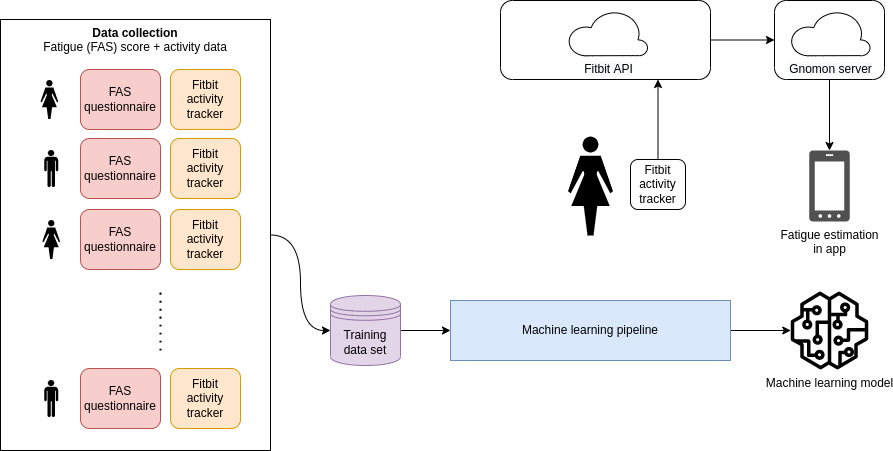

Project overview

# Summary session 1

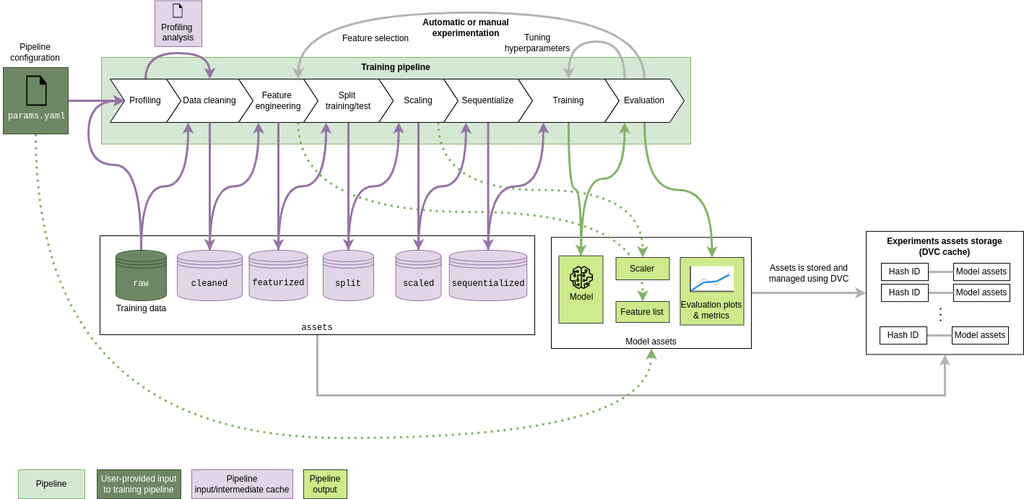

Pipeline details

# Requirements

- One of the following operating systems:
  - Linux (RECOMMENDED)
  - macOS
  - Windows with WSL (Windows Subsystem for Linux)
  - Windows (NOT recommended, might be difficult to get things running depending on how you install Python)
- The following software needs to be installed:
  - Python
  - Git
  - [DVC](https://dvc.org/)

# Overview of approach

1. **Installation**
2. **Restructure** raw data:

```
python3 src/fitbit.py [FILEPATH_TO_RAW_DATA]
```

3. **Place** the data files (output of previous step) in `assets/data/raw`.
4. **Configure** parameters in `params.yaml`.
5. **Run** the pipeline:

```
dvc repro
```

# Installation

1. Download the source code using `git`: github.com/ejhusom/bluehealthpass-ml

```
git clone https://github.com/ejhusom/bluehealthpass-ml.git
```

2. Installing required Python-packages:

```
cd bluehealthpass-ml
mkdir venv
python3 -m venv venv
source venv/bin/activate
pip3 install -r requirements.txt
```

3. Set up DVC:

```
dvc init --no-scm
```

# Data restructuring

- Run the following command:

```
python3 src/fitbit.py [FILEPATH_TO_RAW_DATA]
```

Example:

```
python3 src/fitbit.py ~/Onedrive/Datasets/Fitbit/BlueHealthPass_CompleteRawDataset
```

- Create folder for data: `assets/data/raw/[DATASET_NAME]`
- Place the restructured data files in `assets/data/raw`:

```
mv *.csv assets/data/raw/[DATASET_NAME]
```

# Balance the distribution

- Rename files to assign them to the training or test set.
  - A suggestion for the splitting is automatically created by `fitbit.py`, but it is not robust.
  - This is another suggestion:
    - Training set IDs: 01, 04, 07, 10, 18, 20, 22, 23, 24, 26, 29, 34, 35, 36, 37, 39, 40, 42
    - Test set IDs: 02, 03, 05, 08, 12, 13, 14, 16, 19, 21, 27, 28, 31, 32, 33, 38, 41
  - For the tutorial: Use the files in the zip-folder `bhp_restructured.zip`

# Configure parameters

We take a look at the parameters in the live session.

# Run the pipeline

```
dvc repro
```

# Inspect results

Files

- `assets/plots/prediction.html`
- `assets/plots/trainingloss.png`
- `assets/plots/true_vs_pred.png`

# Tracking results with git

(This is an optional section of the session, if we have time.)

Remove these lines from `.gitignore`:

```
.dvc*
dvc.lock
assets/plots/
assets/profile/
assets/metrics/
assets/scalers/
assets/predictions/
assets/features/
assets/models/
```

Set up DVC with source code management (SCM):

```
dvc init
```

# Tracking results with git

- Run experiments with `dvc exp run`
- Plots and DVC log will be tracked by Git
- Large files (models, profiling reports) will not be tracked by Git
  - DVC handles these files in cache
  - DVC can be synced with cloud storage to keep track of these files
- See metrics with: `dvc metrics show`
- Compare metrics with: `dvc metrics diff`
- Compare experiments with: `dvc exp show --pcp --all-branches --sort-by r2`

# More on DVC

- Learn more here:
  - [DVC: Versioning Data and Models](https://dvc.org/doc/use-cases/versioning-data-and-models)
  - [DVC: Tutorial: Data and Model Versioning](https://dvc.org/doc/use-cases/versioning-data-and-models/tutorial)

# Questions

- Any questions?

# End of session 2